# Metapopulation dynamics

March 21, 2022

## Spatial-structure

Simple population: \[\large N(t)\]

Age-structured: \[\large N_i(t) = \{N_1(t), N_2(t), ..., N_k(t)\}\]

- where \(i\) represents age structure, with \(k\) age stages

Spatial structure: \[\large N_i(t) = \{N_1(t), N_2(t), ..., N_k(t)\}\]

- where \(i\) is location, with \(k\) locations

## A metapopulation …

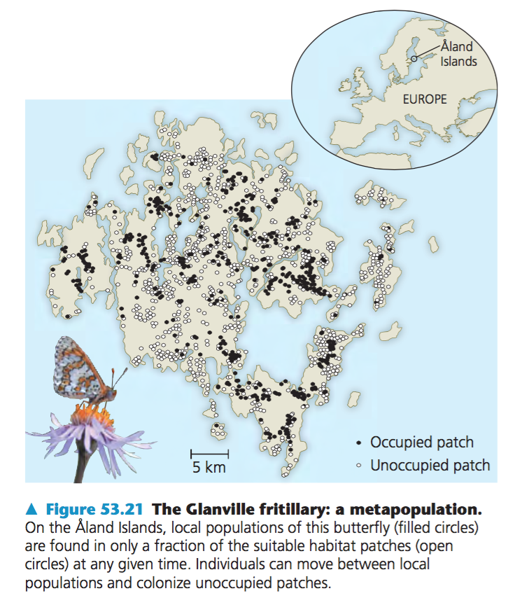

### … is a **population of populations**

The local populations MUST be somehow connected via **dispersal**.

There must be areas of (near) zero density in between. The “in-between” is referred to as the **matrix**.

### Examples

- Island populations
- Fragmented habitats
- Humans
- Just about anything with *genetic structure*!

## “Population” vs. “Metapopulation”

**WA sea otters**

- closed population
- individuals living in same place, same time
- only **B**irth and **D**eath
- Interested in: growth / dynamics / age structures
- Extinction mainly relevant under stochastic scenarios

**All sea otters**

- open population
- individuals in different places, at the same time
- **I**mmigration and **E**migration key processes
- the main question of interest is **presence** / **absence**
- given that local populations go **extinct**, will the metapopulation go **extinct**?
- what is the proportion of occupied patches?

## Population persistence

\(e\) = *local* probability of extinction

- 1 time step: \(1-e\)
- 2 time steps: \((1-e)(1-e)\)
- 3 time steps: \((1-e)(1-e)(1-e)\)
- 4 time steps: \((1-e)(1-e)(1-e)(1-e)\)
- \(t\) time steps: \((1-e)^t\)

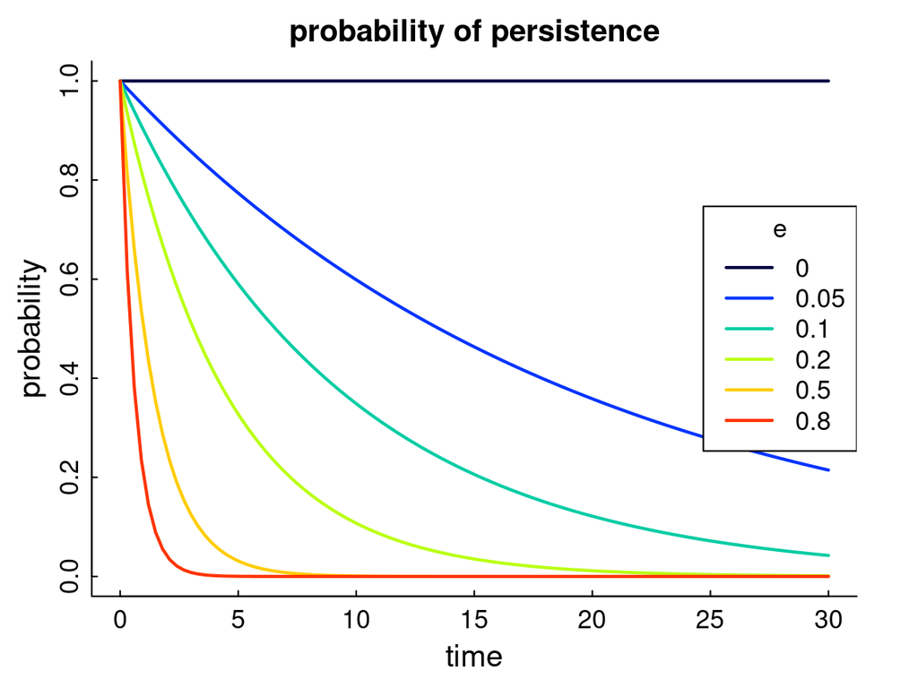

**Take away:** Even with very LOW probability of extinction, you WILL go extinct.

## Metapopulation persistence

\(k\) populations, \(t\) time steps

| Pops: | One time step | t steps |
| --- | --- | --- |
| 1: | \(1-e\) | \((1-e)^t\) |
| 2: | \(1-e \times e\) | \((1-e^2)^t\) |
| 3: | \(1-e \times e \times e\) | \((1-e^3)^t\) |
| k: | \(1-e^k\) | \((1-e^k)^t\) |

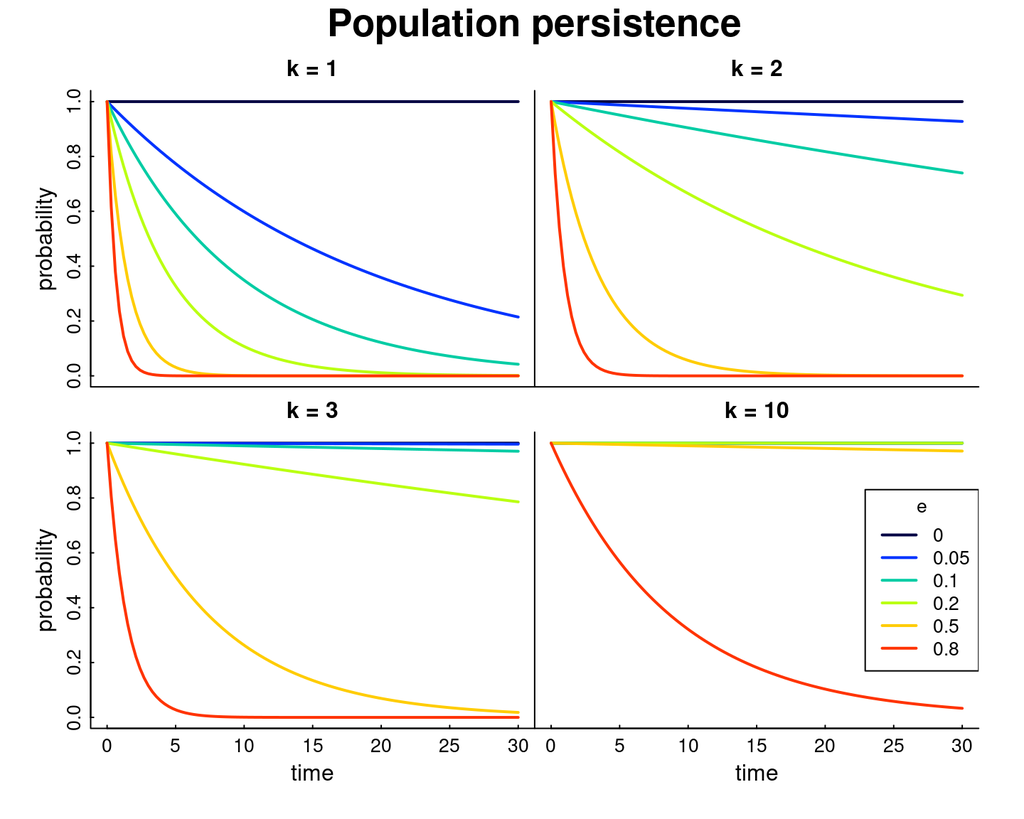

## Metapopulations are resistant to extinction

Metapopulations DRAMATICALLY spread out the risk of extinction!

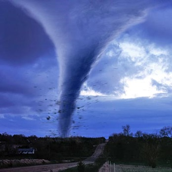

But still - if ONLY process is extinction … you WILL go extinct (sorry!)

\[P(k,t) = (1-e^k)^t\]

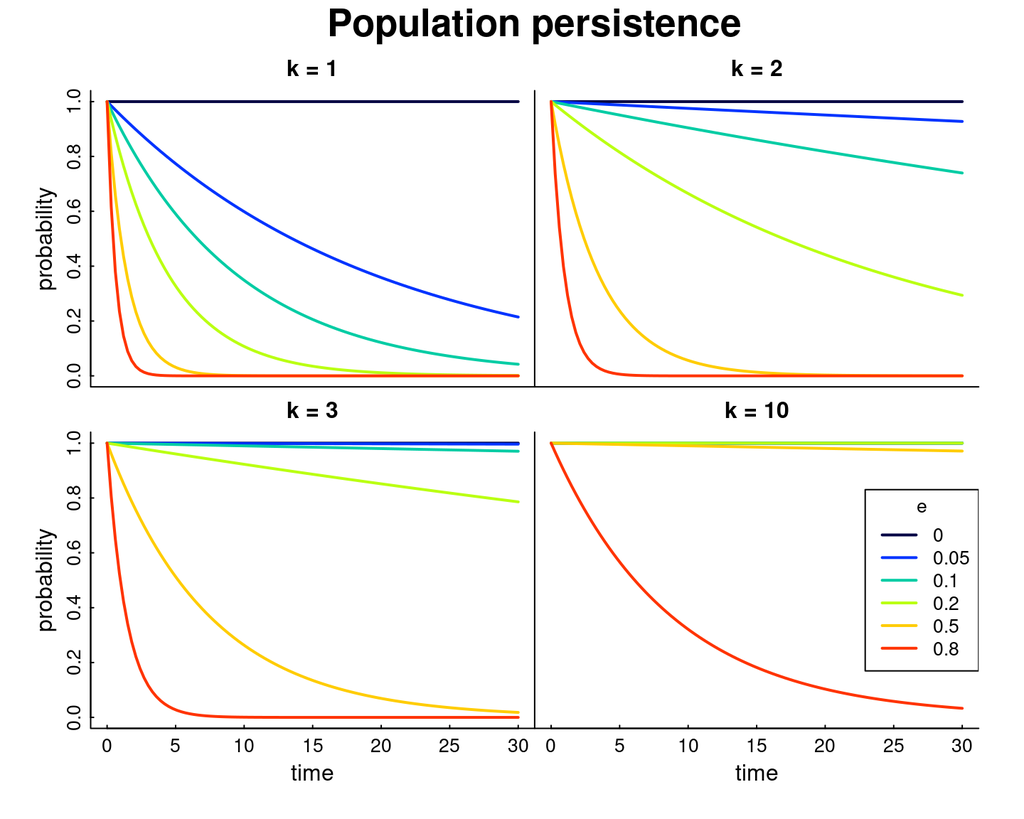

## M1: Let’s add **colonization**

**Island-Mainland model**

- Every (local) population has a probability of going extinct: \(p_e\)
- But every empty location has a probability of getting colonized: \(p_c\)

Note - there is also here an important (implicit) assumption that population very quickly hits **carrying capacity**, so essentially *instant* saturation.

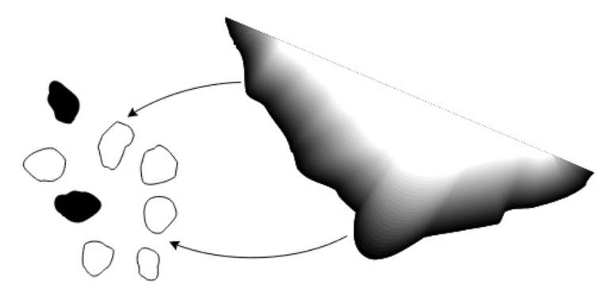

The mainland is a constant, independent source of potential colonizers. Also known as **propagule rain**.

(echoes of *biogeography*).

## M1: Island-Mainland Model

### Q: How many occupied patches might we expect?

\[E(N_{t+1}) = N_t - p_e N_t + (K - N_t)\,p_c\]

define proportion of populated patches: \(f_t = E(N_t)/K\), and define *equilibirum*: \[f^* = f_{t+1} = f_t\]

*…then some math happens…*

\[\large f^* = {p_c \over p_c + p_e}\]

## Continuous time formulation

Very general metapopulation model: \[\large {df \over dt} = c - e\]

Where \(c\) - colonization rate, \(e\) - extinction rate.

Note: this is similar to \({dN \over dt} = b - d\).

(Highly unrealistic) assumptions!

- Deterministic, i.e. number of populations \(K \to \infty\)
- Continuous, unstructured extinction / colonization process
- “Rates” are like infinitesemal probabilities

But - lots of elegant conclusions can be made messing with this model.

## M1: Mainland-Island

\[\large {df \over dt} = c - e\]

Colonization is constant, so proportional to **available** patches: \[c = p_c(1-f)\]

Extinction is constant, so proportional to **occupied** patches:

\[e = p_e f\]

so: \[ {df \over dt} = p_c(1-f) - p_ef\]

in words: **The rate of change of the occupied patches GROWS in proportion to unoccupied patches and FALLS in proportion with occupied patches.**

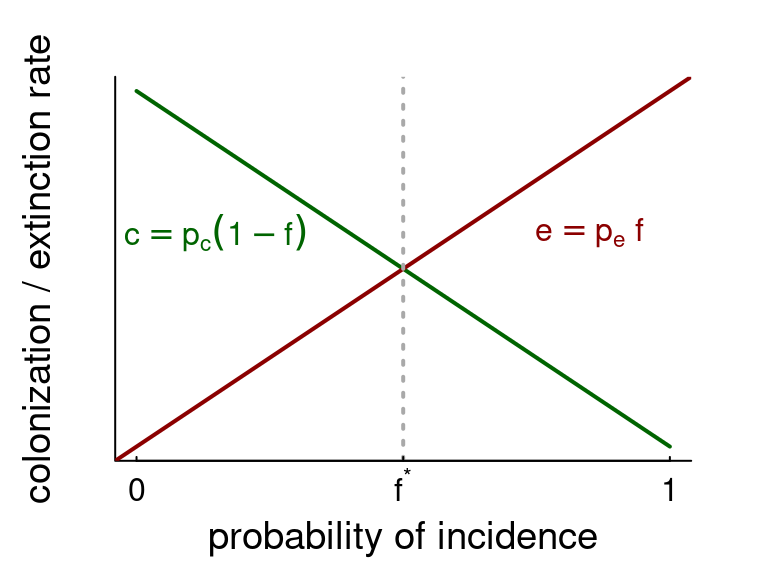

## M2: Internal Colonization

\[ {df \over dt} = p_c f(1-f) - p_ef\]

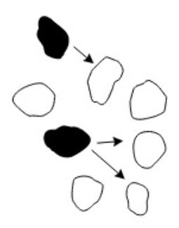

Extinction is constant, as before: \[e = p_e f\]

Colonization can only come from **occupied** patches: \[c = p_c \, f \, (1-f)\]

If no patch is colonized (\(f=0\)), nothing can colonize.

If the population is 100% occupied (\(f = 1\)), there is nothing to colonize.

## M2: Internal Colonization - with Schematic

\[ \large {df \over dt} = p_c f(1-f) - p_ef\]

- If no site is colonized (\(f=0\)), nothing can colonize.
- If the population is 100% occupied \((f = 1)\), there is nothing to colonize.
- The maximum rate of colonization occurs when \(f = 1/2\).
- **Equilibrium** occurs when: \[f^* = \begin{cases} 1-p_e/p_c & \text{when} & p_e < p_c \\ 0 & \text{when} & p_e \geq p_c\end{cases}\]

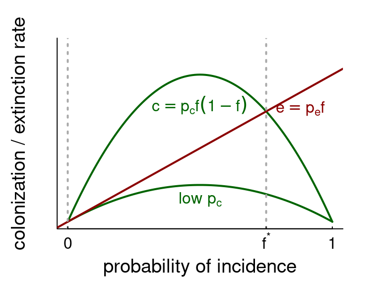

## M3: Rescue Effect

\[ \large {df \over dt} = p_c (1-f) - p_ef(1-f)\]

Assumes that if you have a lot of neighbors some loose “propagules” will buffer you from extinction.

**Equilibrium states:**

\[f^* = \begin{cases} p_c/p_e & \text{when} & p_e > p_c \\ 1 & \text{when} & p_e \leq p_c\end{cases}\]

Even with higher extinction rate than colonization rate, there will always be some occupied patches!

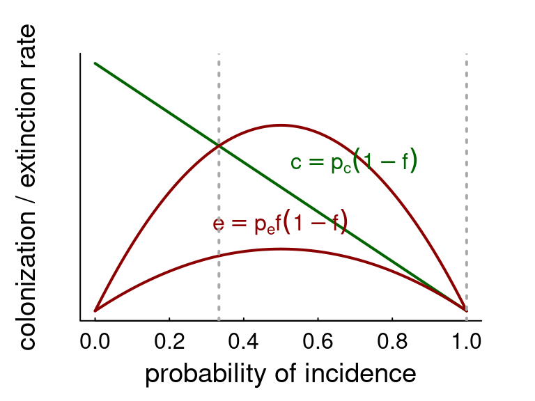

## M4: Rescue Efffect with Internal Colonization

\[ \large {df \over dt} = p_c f(1-f) - p_ef(1-f)\]

Only equilibria: 0, if \(p_e > p_c\) or 1, if \(p_e \leq p_c\).

Fundamental conclusions: **metapopulation under equilibrium MUST be rare! - either everything colonizes or nothing colonizes.**

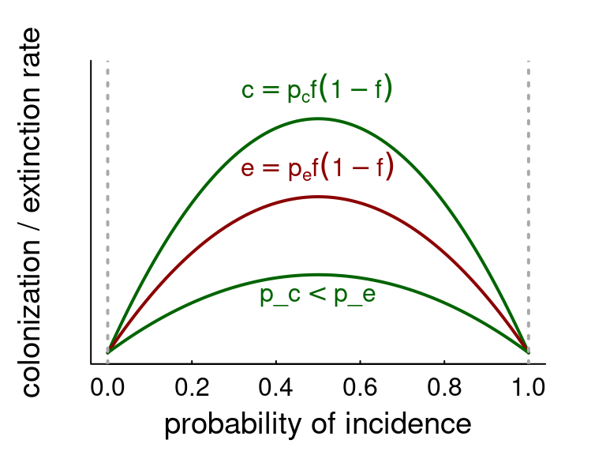

## Four models

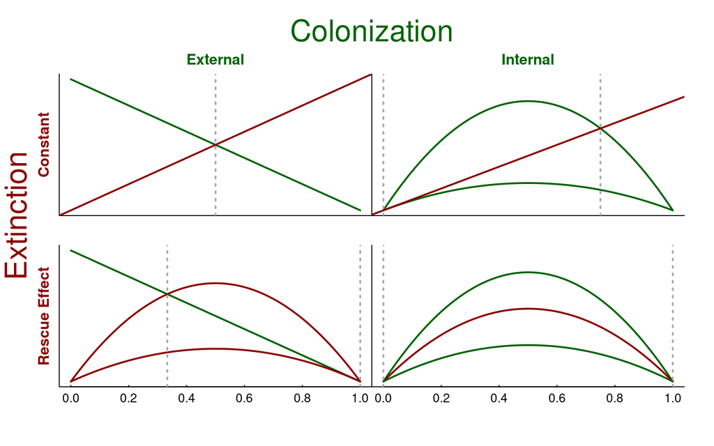

With rather different predictions! (Nice synthesis - mainly due to Gotelli.)

## Some characters

### Richard Levins (1930-2016)

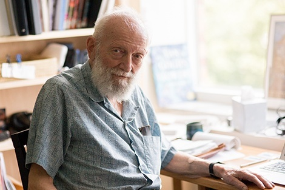

- “Scholarship that is indifferent to human suffering is immoral.”
- “Our truth is the intersection of independent lies.”

### Ilkka Hanski (1953-2016)

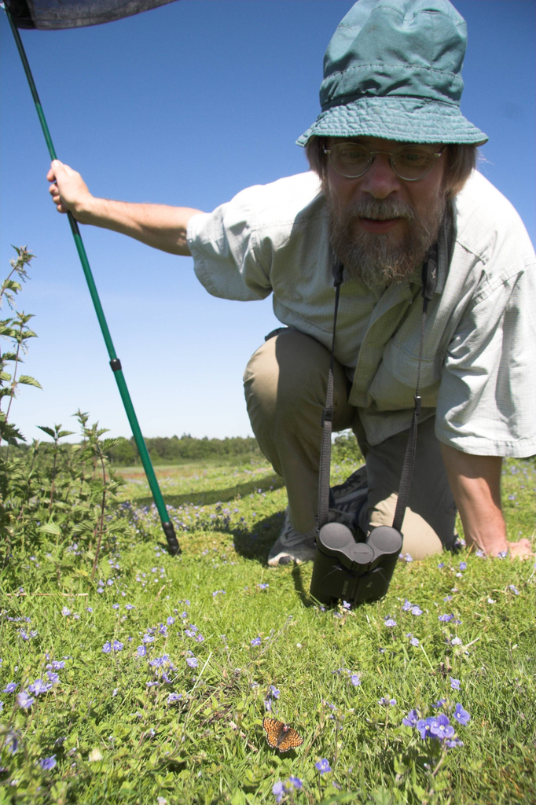